# Fundamentos de Regresión y Modelos Estacionarios

Fernando Salcedo Mejía, Economista, MSc

Escuela de Transformación Digital - ETD | Programa de Ciencia de Datos

2026-02-01

## Contenido del curso

**Tip**

En esta unidad se abordan los principios de los modelos de regresión aplicados a las series temporales. Se introducen los conceptos de estacionariedad, autocorrelación y autocovarianza, y cómo estos son fundamentales para trabajar con modelos de series temporales.

- Regresión simple y múltiple en el contexto de las series temporales
- Estacionariedad en series temporales
- Funciones de autocorrelación y autocovarianza
- Análisis de la autocorrelación y parcial autocorrelación en series temporales
- Modelos autoregresivos (AR) y medias móviles (MA)

## Objetivos de aprendizaje

Al finalizar esta unidad, el estudiante será capaz de :

- Estimar e interpretar los coeficientes de un modelo de regresión lineal aplicado a series de tiempo mediante Mínimos Cuadrados Ordinarios (MCO).
- Verificar los supuestos del modelo de regresión lineal (linealidad, homocedasticidad, no autocorrelación, exogeneidad) y diagnosticar su cumplimiento a partir de los residuos.
- Construir predictores temporales (tendencia, variables dummy, series de Fourier) para capturar patrones estacionales.
- Generar pronósticos con sus respectivos intervalos de confianza y evaluar su precisión con métricas como AIC, BIC, RMSE, MAE, MAPE y MASE.

## Regresión lineal en series de tiempo

**Concepto clave**

Podemos aplicar el concepto de regresión para pronosticar una variable $y_t$ asumiendo que tiene una relación esperada con otra en el tiempo $x_t$.

$$y_t = \beta_0 + \beta_1 x_{1, t} + \beta_2 x_{2, t} + \dots + \beta_k x_{k, t} + \varepsilon_t$$

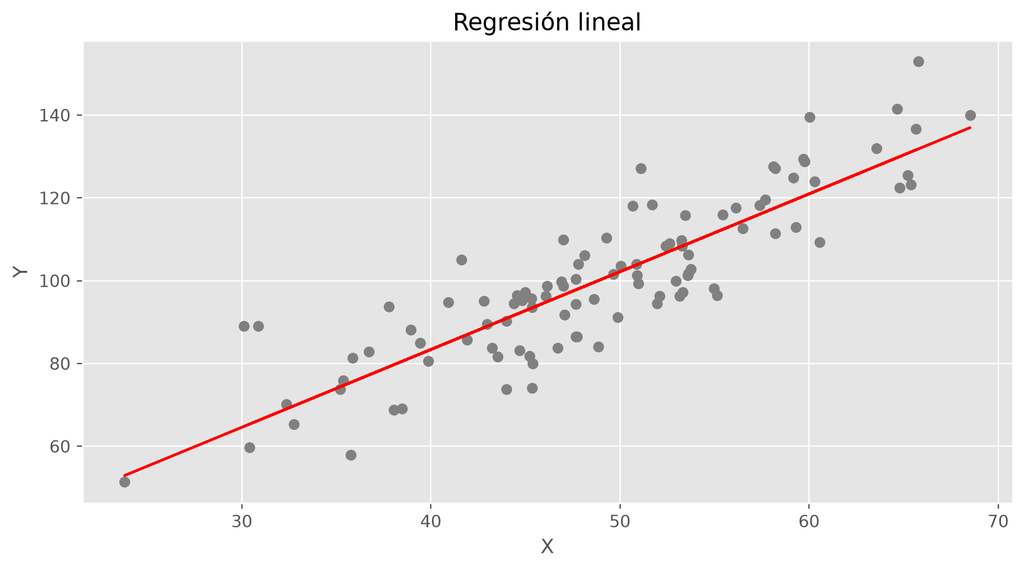

```python
import numpy as np
import matplotlib.pyplot as plt
import statsmodels.api as sm

np.random.seed(42)
x = np.random.normal(50, 10, 100)
y = np.random.normal(2, 10, 100) + 2 * x + np.random.normal(0, 1, 100)
X = sm.add_constant(x)
lm = sm.OLS(y, X).fit()
y_hat = lm.predict()

plt.style.use('ggplot')
fig, ax = plt.subplots()
ax.scatter(x, y, color = "gray")
ax.plot(x, y_hat, color = "red")
plt.title('Regresión lineal')
plt.xlabel('X')
plt.ylabel('Y')
fig.show()
```

## Estimador Minimos Cuadrados Ordinarios (MCO)

**Definición**

El estimador MCO permite buscar los coeficientes $\beta_k$ de una regresión tal que **minimiza la suma de los errores (el valor más pequeño)** de la regresión.

$$\varepsilon_t = y_t - \hat{y}_t \\
\hat{y}_t = \beta_0 + \beta_1 x_{1, t} + \beta_2 x_{2, t} + \dots + \beta_k x_{k, t} + \varepsilon_t$$
$$\sum_{t=1}^T \varepsilon_t^2 = \sum_{t=1}^T (y_t -
\beta_{0} - \beta_{1} x_{1,t} - \beta_{2} x_{2,t} - \cdots - \beta_{k} x_{k,t})^2.$$

- Supuesto $\hat{\varepsilon_{t}} \sim N(0, \sigma^2)$

## Gráfico conceptual del MCO

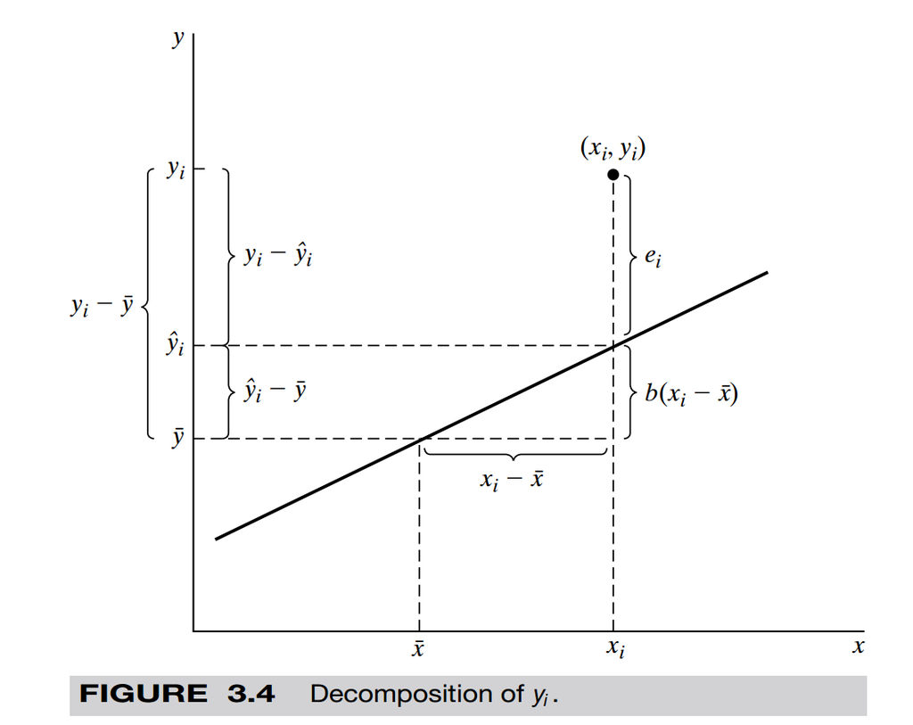

Referencia : Tomando de Green (2012) Econometric Analysis . 7 ed.

## Estimador MCO modelo lineal simple

- Para un modelo $Y_t = \beta_0 + \beta_1X_t$. El estimador por *MCO* para $\beta_1$ sería

$$\hat{\beta_1} = \frac{\sum(X_t - \overline{X})(Y_t - \overline{Y})}{\sum(X_t - \overline{X})^2} \\
\hat{\beta_0} = \overline{Y} - \hat{\beta_1}\overline{X}$$

## Estimador MCO modelo general

- Tenemos el siguiente modelo lineal múltiple
  $$y_t = \beta_0 + \beta_1 x_{1, t} + \beta_2 x_{2, t} + \dots + \beta_k x_{k, t} + \varepsilon_t \\
  \varepsilon_{t} \sim N(0, \sigma^2)$$
- Para encontrar los $\hat{\beta}$ por *MCO* conviene expresarlo en términos matriciales así :

$$\left[
\begin{matrix}
y_1 \\
y_2 \\
\vdots \\
y_T
\end{matrix}
\right] =
\left[
\begin{matrix}
1 & x_{1,1} & x_{2,1} & \dots & x_{k,1}\\
1 & x_{1,2} & x_{2,2} & \dots & x_{k,2}\\
\vdots& \vdots& \vdots&& \vdots\\
1 & x_{1,T}& x_{2,T}& \dots& x_{k,T}
\end{matrix}
\right] \times
\left[
\begin{matrix}
\beta_1 \\
\beta_2 \\
\vdots \\
\beta_k
\end{matrix}
\right] +
\left[
\begin{matrix}
\varepsilon_1 \\
\varepsilon_2 \\
\vdots \\
\varepsilon_T
\end{matrix}
\right] \\$$

- Equivalente a :
  $$\mathbf{y} = \mathbf{X}\mathbf{\beta} + \mathbf{\varepsilon} \\$$
- Donde las dimensiones del sistema $n$ filas, $k$ columnas : $\mathbf{y} = n \times 1$, $\mathbf{X} = n \times k$, $\mathbf{\beta} = k \times 1$ y $\mathbf{\varepsilon} = n \times 1$
- Teniendo en cuenta que *MCO* minimiza el error cuadrático en términos matriciales $\sum_{t=1}^T \varepsilon_t^2 = \mathbf{\varepsilon}'\mathbf{\varepsilon}$

$$\mathbf{\varepsilon}'\mathbf{\varepsilon} = (\mathbf{y} - \mathbf{X}\mathbf{\beta})'(\mathbf{y} - \mathbf{X}\mathbf{\beta})$$

- Expandiendo los términos tenemos :
  $$\mathbf{\varepsilon}'\mathbf{\varepsilon} = \mathbf{y}'\mathbf{y} - \mathbf{\beta}'\mathbf{X}'\mathbf{y} - \mathbf{y}'\mathbf{X}\mathbf{\beta} + \mathbf{\beta}'\mathbf{X}'\mathbf{X}\mathbf{\beta} \\
  \mathbf{\varepsilon}'\mathbf{\varepsilon} = \mathbf{y}'\mathbf{y} - 2\mathbf{y}'\mathbf{X}\mathbf{\beta} + \mathbf{\beta}'\mathbf{X}'\mathbf{X}\mathbf{\beta}$$
- Minimizando la expresión tenemos :
  $$\frac{\partial \mathbf{\varepsilon}'\mathbf{\varepsilon}}{\partial \beta} = -2\mathbf{X}'\mathbf{y} + 2\mathbf{X}'\mathbf{X}\mathbf{\beta} = 0 \\$$
- Resolviendo para $\beta$
  $$2\mathbf{X}'\mathbf{X}\mathbf{\beta} = 2\mathbf{X}'\mathbf{y} \\
  \text{Sistema de ecuaciones normales} :
  (\mathbf{X}'\mathbf{X})^{-1} \mathbf{X}'\mathbf{X}\mathbf{\beta} = (\mathbf{X}'\mathbf{X})^{-1} \mathbf{X}'\mathbf{y}$$
- Finalmente, **tenemos que el estimador *MCO* es :**
  $$\mathbf{\hat{\beta}} = (\mathbf{X}'\mathbf{X})^{-1} \mathbf{X}'\mathbf{y}$$

**Nota**

- Si tenemos un sistema lineal de la forma $\mathbf{A}\mathbf{x} = \mathbf{b}$. La solución del sistema no homogéneo es $\mathbf{x} = \mathbf{A}^{-1} \mathbf{b}$ sí y solo sí $\mathbf{A}$ es una matriz invertible no singular.

**Nota**

- Propiedad la transposición de matrices:
- $(\mathbf{ABC})' = \mathbf{C'B'A'}$.
- Si $\mathbf{A}$ es simétrica entonces $\mathbf{A}'$ = $\mathbf{A}$
- Si $\mathbf{A}$ es inversible sí y solo sí $\mathbf{A}'\mathbf{A} = \mathbf{I}$
- Derivada de una matriz $a'x$, $\frac{\partial (a'x)}{\partial x} = a$
- Derivada de una matriz cuadrática, $x'Ax$ $\frac{\partial (x'Ax)}{\partial x} = 2Ax$

## La interpretación de los $\beta$

- Si tanto $Y$ como $X$ son continuos
  $$\beta_k = \frac{\Delta Y}{\Delta X_k}$$
  $\beta_k$ = El cambio promedio esperado en $Y$ ante un cambio en $X$
- Si $Y$ es númerica y $X$ es dicotómica
  $$\beta_k = E(Y|X = 1) - E(Y|X = 0)$$
  $\beta_K$ = Es la diferencia promedio esperada en $Y$ cuando $X = 1$ respecto a $X = 0$

## Supuestos del modelo lineal

- Las observaciones provienen de una muestra aleatoria de una población
- **Independencia** : $Y_i, .. Y_n$ son independientes
- **Linealidad** : El modelo de regresión es lineal en los parámetros, aunque puede o no ser lineal en las variables.
  - Lineal
    $$Y = \beta_0 + \beta_1 \log X$$
  - No lineal
    $$Y = \beta_0 + 1/\beta_1 X$$
- **Homocedasticidad** : El valor medio del error es igual a cero y La varianza del término de error, o de perturbación, es la misma sin importar el valor de X.
  $$\varepsilon_i \sim N(0, \sigma^2_{\varepsilon})$$
- No hay autocorrelación entre las perturbaciones
  $$Cov(\varepsilon_i, \varepsilon_j) = 0$$
- **Exogeneidad** : Valores de X independientes del término de error $Cov(\varepsilon_i, \mathbf{X}) = 0$
- **Colinealidad perfecta** : no existe correlación perfecta entre las regresoras incluidas en el modelo de regresión $X_1 = 2X_2$
- **Rango completo** : El número de observaciones n debe ser mayor que el número de parámetros por estimar $N > X_k$

## Propiedades del estimador MCO

El supuesto de $\varepsilon \sim N(0, \sigma^2_{\varepsilon})$ tiene las siguientes implicaciones para los parámetros estimados por *MCO*

- **Son insesgados**
  $$E(\hat{\beta_k}) = \beta_k$$
- **Tienen varianza mínima**. En combinación con 1, esto significa que son estimadores insesgados con varianza mínima, o eficientes.
  $$Var(\hat{\beta_0}) = \sigma^2\frac{\sum X^2_i}{n\sum(X_i - \overline{X})^2}, Var(\hat{\beta_1}) = \frac{\sigma^2}{\sum(X_i - \overline{X})^2}$$
- **Presentan consistencia**; es decir, a medida que el tamaño de la muestra aumenta indefinidamente, los estimadores convergen hacia sus verdaderos valores.

## Ejercicio 1. Graficar la convergencia de los parámetros estimados por MCO a sus verdaderos valores.

- Supongamos que los valores de $y$ siguen esta función lineal simple
  $$y = 12 + 20 x + \varepsilon$$
- Donde $\beta_0 = 12$, $\beta_1 = 20$, $X \sim N(12, 24)$ y $\varepsilon \sim N(0, 1)$
- Simular la convergencia de los parámetros estimados por *MCO* según incrementa la muestra.

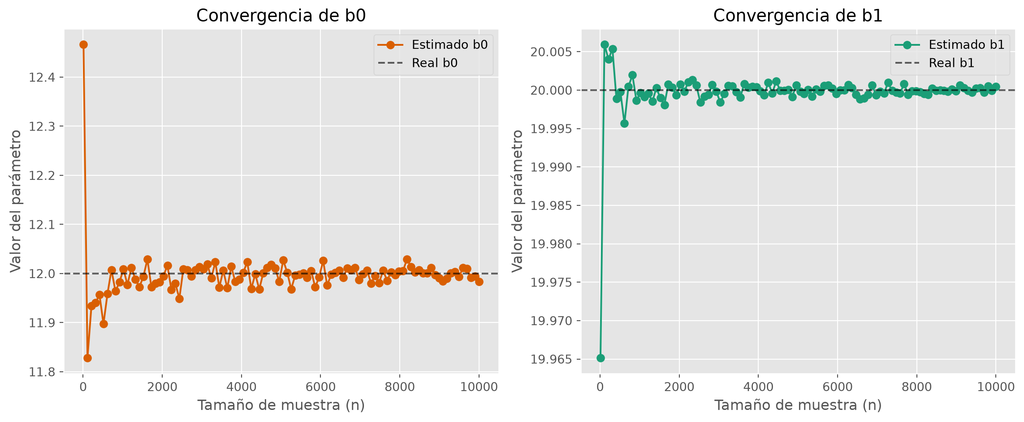

```python
import numpy as np
import matplotlib.pyplot as plt
import statsmodels.api as sm

n_sim = np.linspace(10, 10000, 100).astype(int)
true_beta = {"b0" : 12, "b1" : 20}
x_stats = {"mu" : 12, "sigma" : 24}
beta_hat = {"b0" : [], "b1" : []}

# Generar simulacion
for n in n_sim:
  np.random.seed(42 + n)
  x = np.random.normal(x_stats['mu'], x_stats['sigma'], n)
  y = true_beta['b0'] + true_beta['b1'] * x + np.random.normal(0, 1, n)
  X = sm.add_constant(x)
  lm = sm.OLS(y, X).fit()
  beta_hat['b0'].append(lm.params[0])
  beta_hat['b1'].append(lm.params[1])

plt.style.use('ggplot')
fig, axes = plt.subplots(1, 2, figsize=(12, 5))
colors = ['#d95f02', '#1b9e77']

# Iteramos sobre los resultados para graficar
for i, (key, value) in enumerate(beta_hat.items()):
    axes[i].plot(n_sim, value, label=f'Estimado {key}', color=colors[i], marker='o')
    axes[i].axhline(true_beta[key], color='black', linestyle='--', alpha=0.6, label=f'Real {key}')
    axes[i].set_title(f'Convergencia de {key}')
    axes[i].set_xlabel('Tamaño de muestra (n)')
    axes[i].set_ylabel('Valor del parámetro')
    axes[i].legend()

plt.tight_layout()
plt.show()
```

## Medición del ajuste global del modelo lineal

- La bondad del ajuste mide cuán “bien” se ajusta la línea de regresión a los datos. Se calcula en el coeficiente de determinación $R^2$.
- Esta mide la proporción o el porcentaje de la variación total en $Y$ explicada por el modelo de regresión.
  $$R^2 = \frac{\sum(\hat{y}_{t} - \bar{y})^2}{\sum(y_{t}-\bar{y})^2}$$
- Sus valores $R^2 > 0$ en el rango $0 \leq R \leq 1$

**Note**

Cuando la regresión es simple, es decir con una sola variable regresora $x_t$ el coeficiente de determinación $R^2$ es el mismo que la correlación lineal. Recordemos que, la *correlación lineal* mide la fuerza y el sentido de una relación entre dos variables numéricas.
$$r = \frac{\sum (x_{t} - \bar{x})(y_{t}-\bar{y})}{\sqrt{\sum(x_{t}-\bar{x})^2}\sqrt{\sum(y_{t}-\bar{y})^2}}$$

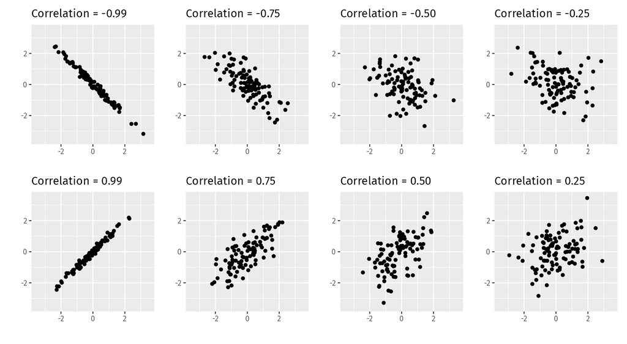

## Significancia de los parámetros

- Los parámetros estimados por *MCO* se le verifica su significancia a través de una prueba de hipótesis

$$H_0: \beta_j = 0$$
$$H_a: \beta_j \neq 0$$

$$t_{1 - \alpha/2; (n - k)} = \frac{\hat{\beta_j} - \beta_j}{\sqrt{Var(\hat{\beta_j})}}$$
- **Regla de decisión :** Si $P(t_{1 - \alpha/2; (n - k)}) < 0.05$ consideramos que hay evidencia suficiente contra $H_0$, por lo que se acepta $H_a$.
$$\text{IC95 \%} = \hat{\beta_j} \pm t_{1 - \alpha/2; (n - k)} \sqrt{Var(\hat{\beta_j})}$$

## Ejemplo 1 : El modelo macroeconómico del crecimiento del consumo en Estados Unidos

- Queremos modelar cómo cambia el consumo real (compra de bienes y servicios) de una economía según variables macroeconómicas importantes. El consumo es uno de los componentes más importantes de una economía.

$$\Delta C_t = \beta_0 + \beta_1 Ingreso_t + \beta_2 Industria_t + \beta_3 Ahorro_t + \beta_4 Desempleo_t + \varepsilon_t$$

- $\Delta C_t$ es el cambio porcentual en el gasto real de consumo personal.
- $Ingreso_t$ es el cambio porcentual en el ingreso personal real disponible.
- $Industria_t$ es el cambio porcentual en la producción industrial.
- $Ahorro_t$ es el cambio porcentual en el ahorro personal.
- $Desempleo_t$ es el cambio en la tasa de desempleo.
- Usar el archivo `US_change.csv` para modelar.

### Solución con statsmodels :

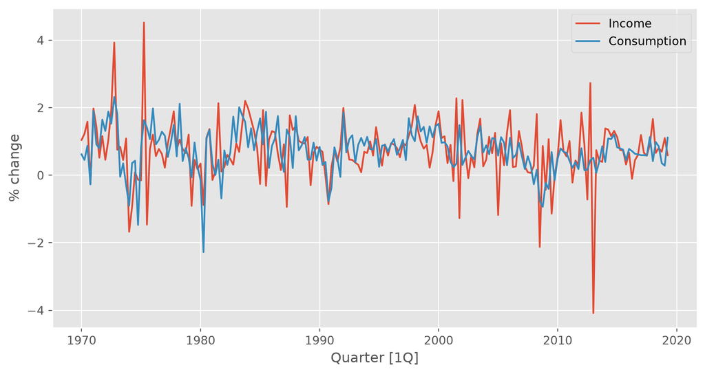

```
                            OLS Regression Results
==============================================================================
Dep. Variable:            Consumption   R-squared:                       0.768
Model:                            OLS   Adj. R-squared:                  0.763
Method:                 Least Squares   F-statistic:                     160.0
Date:                Tue, 11 Aug 2026   Prob (F-statistic):           3.93e-60
Time:                        09:20:27   Log-Likelihood:                -46.660
No. Observations:                 198   AIC:                             103.3
Df Residuals:                     193   BIC:                             119.8
Df Model:                           4
Covariance Type:            nonrobust
================================================================================
                   coef    std err          t      P>|t|      [0.025      0.975]
--------------------------------------------------------------------------------
const            0.2531      0.034      7.343      0.000       0.185       0.321
Income           0.7406      0.040     18.461      0.000       0.661       0.820
Production       0.0472      0.023      2.038      0.043       0.002       0.093
Savings         -0.0529      0.003    -18.088      0.000      -0.059      -0.047
Unemployment    -0.1747      0.096     -1.829      0.069      -0.363       0.014
==============================================================================
Omnibus:                       19.961   Durbin-Watson:                   2.218
Prob(Omnibus):                  0.000   Jarque-Bera (JB):               35.767
Skew:                           0.525   Prob(JB):                     1.71e-08
Kurtosis:                       4.798   Cond. No.                         53.6
==============================================================================

Notes:
[1] Standard Errors assume that the covariance matrix of the errors is correctly specified.
```

```python
import pandas as pd
import matplotlib.pyplot as plt
import statsmodels.api as sm

# datos US_change
us_change = pd.read_csv("datos/US_change.csv", parse_dates=["ds"])
us_change.index = us_change.ds

fig, ax = plt.subplots()
ax.plot(us_change["ds"], us_change["Income"], label="Income")
ax.plot(us_change["ds"], us_change["y"], label="Consumption")
ax.set(xlabel="Quarter [1Q]", ylabel="% change")
ax.legend()
plt.show()

# Modelo MCO
columns = ["y", "Income", "Production", "Savings", "Unemployment"]
df = us_change[columns].rename(columns={'y': 'Consumption'})
y = df[["Consumption"]]
X = df[["Income", "Production", "Savings", "Unemployment"]]

X = sm.add_constant(X)
ml = sm.OLS(y, X).fit()
print(ml.summary())
```

### Solución con R :

**Note**

Este bloque se muestra como referencia (`eval: false`) y no se ejecuta al renderizar, ya que el motor del documento (`engine: jupyter`) corre la solución en Python. Puedes ejecutarlo de forma independiente en una sesión de R.

```r
# | eval: false
# Cargar librerías necesarias
library(tidyverse)
library(fable)
library(tsibble) # 'tsibble' para series de tiempo

# 1. Cargar y preparar datos
us_change <- read_csv("datos/US_change.csv") |>
  mutate(ds = yearquarter(ds)) |>
  as_tsibble(index = ds)

# 2. Visualización
ggplot(us_change, aes(x = ds)) +
  geom_line(aes(y = Income, color = "Income")) +
  geom_line(aes(y = y, color = "Consumption")) +
  labs(x = "Quarter [1Q]", y = "% change", color = "Variable") +
  theme_minimal()

# 3. Modelo de Regresión Lineal (MCO)
# Usamos TSLM (Time Series Linear Model) de la librería 'fable'
fit <- us_change |>
  model(
    mco = TSLM(y ~ Income + Production + Savings + Unemployment)
  )

# 4. Resumen del modelo
report(fit)
```

## Evaluando el modelo MCO

- Tras seleccionar las variables de regresión y ajustar el modelo, es necesario graficar los residuos para verificar que se han cumplido los supuestos del modelo.
- Recordemos que los errores de estimación del modelo :
  $$\varepsilon_t = y_t - \hat{y}_t \\
  \varepsilon_t = y_t - \hat\beta_{0} - \hat\beta_{1} x_{1,t} - \hat\beta_{2} x_{2,t} - \cdots - \hat\beta_{k} x_{k,t} \\
  \sum_{t=1}^{T}{e_t}=0 \quad\text{and}\quad \sum_{t=1}^{T}{x_{k,t}e_t}=0\qquad\text{for all $k$}. \\
  \text{Para todo} t=1,\dots,T$$

### Linealidad de los paramentros

- La relación de las variables regresoras deben ser lineales con la variables explicada. Gráficamente, no debemos ver un patrón funcional entre los errores y los valores predichos del modelo.

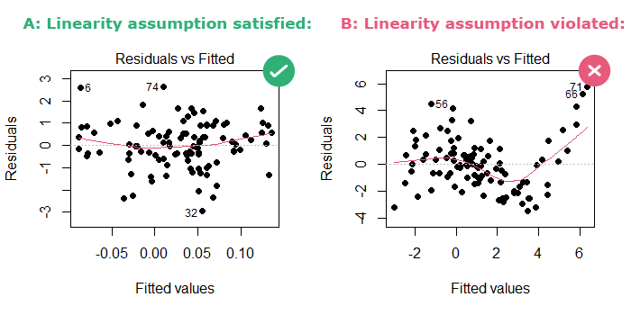

### Distribución de los errores son normales

- Al hacer un histograma de los errores del modelo buscamos observar distribuciones sesgadas o no propia de la distibución normal.

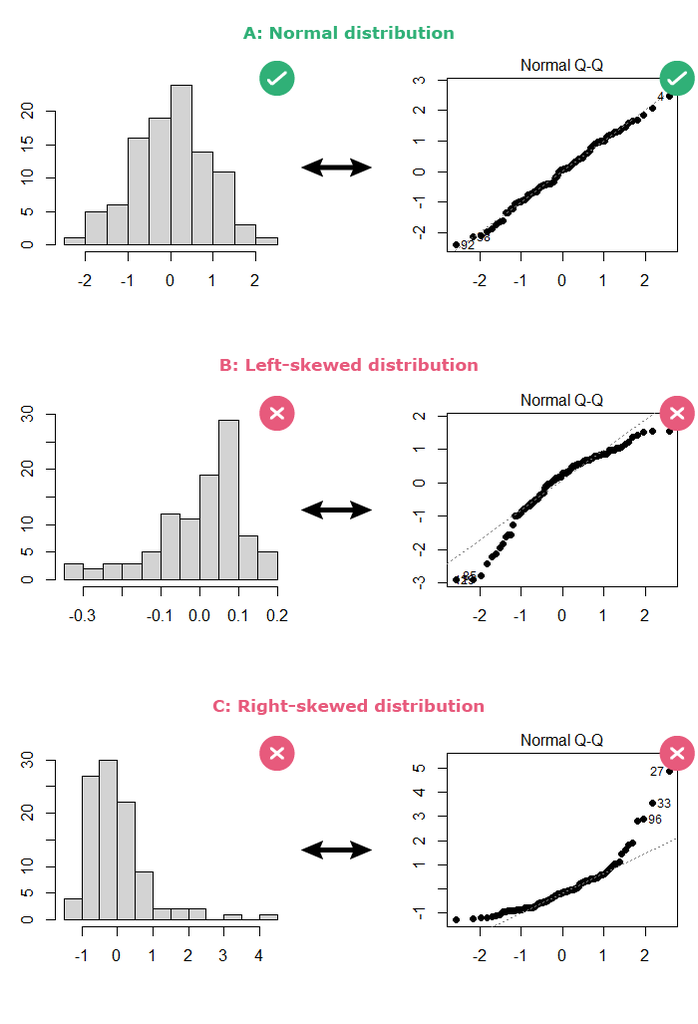

- Para comprobar formalmente podemos ayudarnos de un test de normalidad evalúa si un conjunto de datos puede considerarse proveniente de una distribución normal. Usualmente se utiliza Shapiro–Wilk.

### Residuos del modelo con varianza constante (homocedasticos)

- Los errores del modelo deben distribuirse de forma constante. Gráficamente, no debemos ver un patrón entre los errores y los valores predichos del modelo.

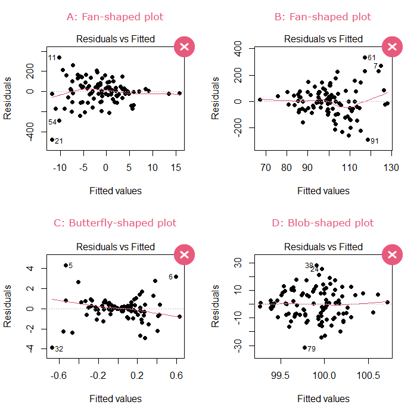

### Residuos no está correlacionados

- **Es usual que los datos temporales tenga correlación con datos anteriores** debido a que sus valores se repiten en el tiempo, como el componente estacional. En este caso, el supuesto de no autocorrelación de los errores del modelo *MCO* se viola y **los estimadores son ineficientes** pero aún son insesgados.

$$Cov(\varepsilon_t , \varepsilon_{t-1}) \neq 0 \\
Cov(X, Y) = \frac{\sum_{i=1}^{n} (x_i - \bar{x})(y_i - \bar{y})}{n - 1}$$

#### Gráfico de Autocorrelación de los residuos (ACF)

- Es un gráfico que mide la correlación que existe entre el valor de una serie de tiempo y su rezago o “lag” $K$

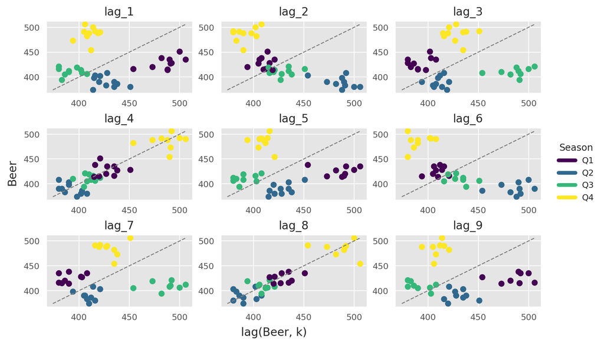

  $$r_{k} = \frac{\sum\limits_{t=k+1}^T (y_{t}-\bar{y})(y_{t-k}-\bar{y})}
  {\sum\limits_{t=1}^T (y_{t}-\bar{y})^2},$$
- Cuando los datos presentan una tendencia, las autocorrelaciones para los rezagos (lags) pequeños tienden a ser grandes y positivas, debido a que las observaciones actuales y anteriores son cercanos entre sí. **Por lo tanto, la función de autocorrelación (ACF) de una serie con tendencia tiende a mostrar valores positivos que decrecen lentamente a medida que los desfases aumentan**.

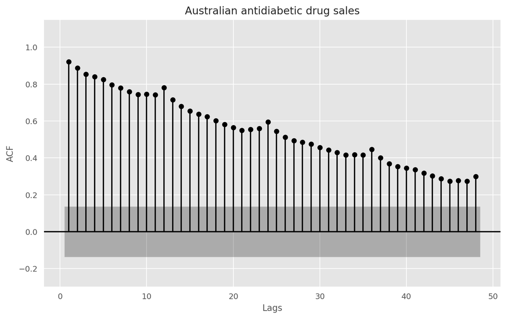

- En cambio, cuando los datos son estacionales, las autocorrelaciones serán mayores para los rezagos estacionales (semanales, trimestrales, anuales, etc) que para otros rezagos.

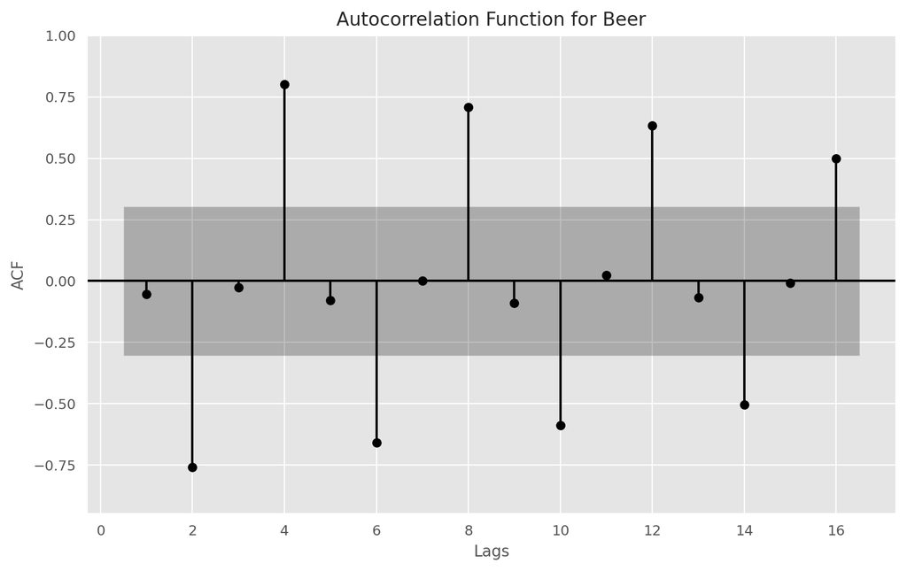

- ¿Puedes análizar estos ACF? ¿Tienen tendencia y estacionalidad?

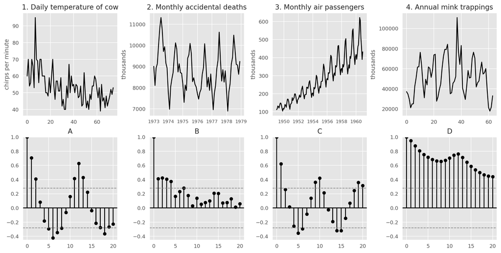

#### Test de Durbin-Watson para la autocorrelación serial

- Es una prueba estadística de prueba que se utiliza para detectar la presencia de autocorrelación en los residuos de un análisis de la regresión.

$$d = \frac{\sum_{t=2}^{T} (e_t - e_{t-1})^2}{\sum_{t=1}^{T} e_t^2} \\
0 \leq d \leq 4$$

- Regla de decisión
- d = 2 indica que no hay autocorrelación
- d < 2 indica correlación serial positiva
- d > 2 indica correlación serial negativa

#### Test de Ljung-Box para la autocorrelación

- Además de observar el gráfico de la ACF, también podemos realizar una prueba más formal de autocorrelación considerando un conjunto completo de rezagados $r_k$ como un grupo, en lugar de tratar a cada uno por separado.

**Important**

Ruido Blanco (White Noise): Una serie donde los datos son totalmente independientes e idénticamente distribuidos. En la ACF, esto se ve como picos que no superan los límites de confianza.

- H0 : Los residuos no están correlacionados hasta el $\ell$ rezagos (**no son** distintos de un proceso ruido blanco)
- Ha : Al menos uno de los residuos está correlacionado hasta el $\ell$ rezago

$$Q^* = T(T+2) \sum_{k=1}^\ell (T-k)^{-1}r_k^2. \\
Q^* \sim \chi ^ 2_{gl = \ell}$$

- **Regla de decisión :** Si $P(Q^*) > 0.05$ la serie sigue un proceso ruido blanco.

#### Soluciones al problema de autocorrelación

- Para una correlación serial positiva, considere agregar rezagos de la variable dependiente y / o independiente al modelo.
  $$y_t = \beta_0 + \beta_1 x_t + \beta_2 y_{t-1} + \varepsilon$$
- Para una correlación serial negativa, verifique que ninguna de sus variables esté sobrediferenciada.
  $$\Delta \Delta x_t$$
- Para la correlación estacional, considere agregar variables ficticias estacionales al modelo.
  $$y_{t} = \beta_{0} + \beta_{1} x_t + \beta_{2}d_{2,t} + \beta_3 d_{3,t} + \beta_4 d_{4,t} + \varepsilon_{t}$$

## Ejercicio 2 :

- Hacer el diagnostico del modelo macroeconómico del crecimiento del consumo en Estados Unidos. ¿Se viola algún supuesto del MCO?

### Solución

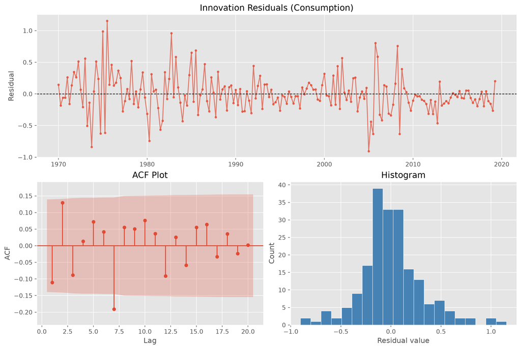

```
PRUEBA DE DIAGNÓSTICO DE RESIDUOS
------------------------------
Durbin-Watson: 2.22 (Objetivo: ≈ 2.0)
Ljung-Box Test (up to lag 20):
 - Min p-value: 0.0211
 - Conclusión: Autocorrelación
```

```python
from statsmodels.graphics.tsaplots import plot_acf
from statsmodels.stats.diagnostic import acorr_ljungbox
from statsmodels.stats.stattools import durbin_watson

def plot_diagnostics(modelo, n_lags=None, target_col="y", time_axis=None):
    if not "statsmodels" in str(type(modelo)):
        raise TypeError("El objeto debe ser un modelo ajustado de statsmodels.")

    # Extraemos residuos directamente del objeto de resultados
    resid = modelo.resid

    # Si no se provee un eje de tiempo, usamos el índice de los residuos
    if time_axis is None:
        time_axis = resid.index

    fig, axes = plt.subplot_mosaic(
        [["resid", "resid"], ["acf", "hist"]],
        figsize=(12, 8),
        constrained_layout=True
    )

    # Gráfico de Residuos
    ax = axes["resid"]
    ax.plot(time_axis, resid, marker='.', linestyle='-', alpha=0.7)
    ax.axhline(0, color='black', linestyle='--', linewidth=1)
    ax.set(title=f"Innovation Residuals ({target_col})", ylabel="Residual")

    # Gráfico ACF
    ax = axes["acf"]
    plot_acf(resid, ax=ax, zero=False, lags=n_lags, auto_ylims=True)
    ax.set(title="ACF Plot", xlabel="Lag", ylabel='ACF')

    # Histograma
    ax = axes["hist"]
    ax.hist(resid, bins=20, edgecolor='white', color='steelblue')
    ax.set(title="Histogram", xlabel="Residual value", ylabel="Count")

    plt.show()

    # Ljung-Box (Prueba global)
    lb_test = acorr_ljungbox(resid, lags=n_lags, return_df=True)
    min_p_value = lb_test['lb_pvalue'].min()
    is_white_noise = min_p_value > 0.05
    # Durbin-Watson (Autocorrelación de primer orden)
    dw_stat = durbin_watson(resid)

    result_test = (
      f"PRUEBA DE DIAGNÓSTICO DE RESIDUOS\n"
      f"{'-'*30}\n"
      f"Durbin-Watson: {dw_stat:.2f} (Objetivo: ≈ 2.0)\n"
      f"Ljung-Box Test (up to lag {n_lags}):\n"
      f" - Min p-value: {min_p_value:.4f}\n"
      f" - Conclusión: {'Ruido Blanco' if is_white_noise else 'Autocorrelación'}"
    )
    print(result_test)

# Ejecución de la función
plot_diagnostics(ml, n_lags=20, target_col="Consumption", time_axis=us_change.index)
```

## Predictores temporales

- Es usual que usemos caracteristicas de la serie temporal en la regresión tales como :

### Tendencia

- La tendencia $T$ se puede modelar incluyéndola como variable explicativa en el modelo
  $$y_{t}= \beta_0+\beta_1t+\varepsilon_t$$

### Variables dummy

- Las variables dummy que son variables que solo toman valores ${0, 1}$ se utilizan para :
- Crear variables estacionales en los datos, tal que capturen patrones específicos de esos momentos. Puedes capturar picos específicos (como Navidad o vacaciones de verano) que una tendencia lineal simple ignoraría.
  $$y_{t} = \beta_{0} + \beta_{1} t + \beta_{2}d_{2,t} + \beta_3 d_{3,t} + \beta_4 d_{4,t} + \varepsilon_{t}$$

**Caution**

**¡Importante! :** Debes dejar siempre una categoría de comparación por lo que la cantidad de dummys a incluir será $d-1$ variables. En `pandas` usamos `get_dummies(drop_first = True)`. Si omites este paso, existe **colinealidad perfecta** y el modelo no se puede estimar.

### Variables dummy estacionales

- Son variables dummy pero que marcan eventos estacionales en la serie, tales como días de la semana, meses de un año, trimestres, etc. Es importante, dejar una variable por fuera del modelo por el riesgo de colinealidad perfecta.
- Un problema que podemos enfrentar es cuando la serie tiene una estacional alta como las series semanales, ya que por año son 52 semanas, lo cual termina en 51 variables dummy estacionales. Recordemos que para cada variable el estimador *MCO* requiere estimar un $\hat{\beta}$ lo cual es más difícil en la medida que incluimos más variables con los mismos datos.

### Series de Fourier

- Es una alternativa a las dummy estacionales, en especial en series con estacionalidad alta. Jean-Baptiste Fourier un matemático Francés describió que las funciones seno y coseno pueden usarse para aproximarse a cualquier serie periódica. Aquí vemos las primeras pares de la serie de seno y cosenos para una estacional de una semana :

$$x_{1,t} = \sin\left(\textstyle\frac{2\pi t}{m}\right),
x_{2,t} = \cos\left(\textstyle\frac{2\pi t}{m}\right),
x_{3,t} = \sin\left(\textstyle\frac{4\pi t}{m}\right)$$

- El máximo de pares de seno y coseno a incluir sería $K=m/2$ donde $m$ es la frecuencia de la estacionalidad de la serie.

## Pronóstico con regresión lineal

- El pronóstico del modelo estimado no es más que usar los $\hat{\beta}$ encontrados por *MCO* sobre una nueva observación de $X$
  $$\hat{y_t} = \hat\beta_{0} + \hat\beta_{1} x_{1,t} + \hat\beta_{2} x_{2,t} + \cdots + \hat\beta_{k} x_{k,t}$$
- Además un intervalo de confianza al 95% para el pronóstico (asumiendo normalidad en los errores del modelo) se define como :
  $$\hat{y} \pm 1.96 \hat{\sigma}_e\sqrt{1+\frac{1}{T}+\frac{(x-\bar{x})^2}{(T-1)s_x^2}}$$

**Pronóstico ex-ante y ex-post**

- **Pronóstico ex-ante :** Son aquellos que se realizan únicamente con los datos que están disponibles previamente de los predictores del modelo.
- **Pronóstico ex-post :** Son aquellos que se realizan utilizando información posterior o nueva sobre los predictores del modelo.
- Otra forma de hacer pronósticos es con la construcción de escenarios, donde suponemos que las variables de nuestro modelo toman un rango de valores esperados en el futuro. Esto es útil para tomadores de decisión si quieren ver valores esperados de la serie bajo supuestos y hacer comparaciones.

## Ejercicio 3:

- Hacer una regresión del consumo con el ingreso en el modelo macroeconómico de Estados Unidos. El ministro de economía del país está interesado en saber cuál será el consumo esperado en el siguiente trimestre en tres escenarios : si el ingreso se mantiene en sus valores promedios históricos, se reduce 0.2 puntos porcentuales o aumenta 0.8 puntos porcentuales respecto al promedio histórico.

$$\Delta C_t = \beta_0 + \beta_1 Ingreso_t + \varepsilon_t$$

- $\Delta C_t$ es el cambio porcentual en el gasto real de consumo personal.
- $Ingreso_t$ es el cambio porcentual en el ingreso personal real disponible.
- Usar el archivo `US_change.csv` para modelar.

## Rendimiento y comparación de modelos para la predicción

- Cuando tenemos varios modelos con diferentes covariables **pero con la misma variable dependiente** podemos usar estadísticos de selección de modelos como :
- $R^2$ ajustado : Permite comparar modelos teniendo en cuenta el número de covariables en el modelo. Entre más alto sea, mejor es el modelo. Al ser un $R^2$ penalizado, este es inferior que el $R^2$.

$$\bar{R}^2 = 1-(1-R^2)\frac{T-1}{T-k-1}$$

Donde $T$ son el número de observaciones y $k$ el número de covariables en el modelo.

- Criterio de información de Akaike : Permite comparar modelos, donde el valor más pequeño es el mejor modelo.

$$\text{AIC} = T\log\left(\frac{\text{SSE}}{T}\right) + 2(k+2),$$

Donde $T$ son el número de observaciones y $k$ el número de covariables en el modelo.

- Criterio Bayesiano de información (BIC) : Al igual que el AIC, Permite comparar modelos, donde el valor más pequeño es el mejor modelo.

$$\text{BIC} = T\log\left(\frac{\text{SSE}}{T}\right) + (k+2)\log(T).$$

- Para hacer pronósticos, nos interesa verificar la precisión del modelo usando los errores de estimación $\varepsilon_t = y_t - \hat{y}_t$. Para ello, verificamos qué tanto se equica mi modelo con los datos, donde vamos a seleccionar el modelo con el menor error posible. **En la práctica necesitamos dividir la serie en un segmento para estimar el modelo y otro para verificar el rendimiento.**

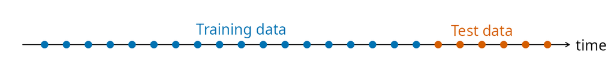

- Error absoluto promedio (MAE) : $\text{Mean absolute error: MAE} = \text{mean}(|e_{t}|)$
- Raíz del error promedio cuadrático (RMSE) : $\text{Root mean squared error: RMSE} = \sqrt{\text{mean}(e_{t}^2)}$
- Porcentaje de error promedio (MAPE) : $\text{Mean absolute percentage error: MAPE} = \text{mean}(|100 e_{t}/y_{t}|).$
- Promedio absoluto de los errores escalados (MASE) :
  $$q_{j} = \frac{\displaystyle e_{j}}{\displaystyle\frac{1}{T-1}\sum_{t=2}^T |y_{t}-y_{t-1}|} \\
  \text{MASE} = \text{mean}(|q_{j}|)$$
- Raíz del error cuadrático escalado (RMSSE) : $\text{RMSSE} = \sqrt{\text{mean}(q_{j}^2)}$
- Una técnica más avanzada es la validación cruzada (CV), donde el objetivo es mover el punto de cohorte del modelo e ir verificando el rendimiento en el conjunto de datos posterior. Luego se promedia un estadístico de precisión del pronóstico (usualmente MAE):

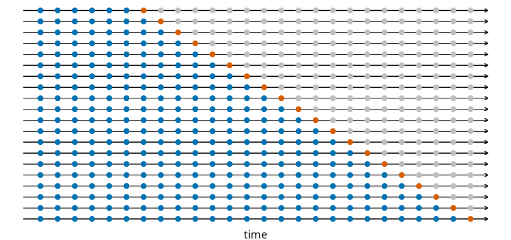

- Elimine la observación $t$ del conjunto de datos y ajuste el modelo utilizando los datos restantes. Luego, calcule el error ($e_{t}^*=y_{t}-\hat{y}_{t}$) para la observación omitida. (Note que este no es el mismo valor que el residuo, ya que la t-ésima observación no se utilizó para estimar el valor de $\hat{y}_{t}$).
- Repita el paso 1 para cada $t=1,\dots,T$.
- Calcule el MSE (Error Cuadrático Medio) a partir de $e_{1}^*,\dots,e_{T}^*$. A este resultado lo llamaremos CV.

## Ejercicio 4:

- Usando el modelo macroeconómico del cambio en el consumo de Estados Unidos, compara el rendimiento de todas la combinaciones (16 modelos en total) de covariables disponibles en términos de $Ingreso_t$, $Industria_t$, $Ahorro_t$, $Desempleo_t$.
- Calcular : AIC, BIC, CV, RMSE, MAE, MAPE, MASE para cada modelo.
- Finalmente, compare los resultados y seleccione el mejor modelo.

## Resumen

- La regresión lineal, estimada por MCO, permite modelar y pronosticar una serie de tiempo a partir de su relación con otras variables.
- El estimador MCO es insesgado, de varianza mínima y consistente **si y solo si** se cumplen sus supuestos (linealidad, homocedasticidad, no autocorrelación, exogeneidad, no colinealidad perfecta).
- En datos temporales, la autocorrelación de los residuos es la violación más común: se diagnostica con ACF, Durbin-Watson y Ljung-Box, y se corrige agregando rezagos, diferenciando o incluyendo variables estacionales.
- Predictores como la tendencia, las variables dummy estacionales y las series de Fourier permiten capturar el comportamiento temporal dentro de un modelo lineal.
- La selección del mejor modelo combina criterios de ajuste penalizado ($\bar R^2$, AIC, BIC) con medidas de error de pronóstico fuera de muestra (RMSE, MAE, MAPE, MASE) y validación cruzada.

## Referencias

- Greene, W. H. (2012). *Econometric Analysis* (7th ed.). Pearson.
- Hyndman, R. J., & Athanasopoulos, G. (2021). *Forecasting: Principles and Practice* (3rd ed.). OTexts. otexts.com/fpp3